# Cooperativas Data Analysis

```python
# Importamos las librerías necesarias para el análisis

# pandas es una librería que nos permite manejar y analizar datos de manera eficiente
import pandas as pd

# os es una librería que nos ayuda a interactuar con el sistema de archivos, como abrir, leer o guardar archivos
import os

# matplotlib.pyplot es una librería para crear gráficos y visualizaciones
import matplotlib.pyplot as plt

# seaborn es una librería basada en matplotlib que facilita la creación de gráficos más atractivos
import seaborn as sns

# numpy es una librería para trabajar con grandes cantidades de datos numéricos y realizar cálculos matemáticos
import numpy as np
```

## 1. Carga de Datos

```python
# Ajustamos la ruta de la carpeta 'output' donde están almacenados nuestros archivos de datos
# Usamos os.path.abspath para obtener la ruta absoluta y subimos un nivel desde la ubicación del notebook actual
output_folder = os.path.abspath('../output')

# Verificamos si la carpeta 'output' existe en el sistema
if not os.path.exists(output_folder):
    # Si no existe, imprimimos un mensaje informativo con la ruta de la carpeta
    print(f"Carpeta '{output_folder}' no existe en: {output_folder}")
else:
    # Si la carpeta existe, buscamos todos los archivos que terminan en '.csv' (archivos de datos)
    csv_files = [f for f in os.listdir(output_folder) if f.endswith('.csv')]

    # Verificamos si se encontraron archivos CSV en la carpeta
    if not csv_files:
        # Si no hay archivos CSV, mostramos un mensaje informativo
        print(f"No se encontraron archivos CSV en la carpeta '{output_folder}'")
    else:
        # Creamos un diccionario vacío donde almacenaremos los DataFrames con los archivos CSV cargados
        dataframes = {}
        for file in csv_files:
            # Para cada archivo CSV encontrado, obtenemos su ruta completa
            file_path = os.path.join(output_folder, file)
            # Cargamos el archivo CSV en un DataFrame de pandas y lo almacenamos en el diccionario
            dataframes[file] = pd.read_csv(file_path)
            # Imprimimos el nombre del archivo que fue cargado exitosamente
            print(f"Archivo cargado: {file}")
```

```
Archivo cargado: aportes_092024.csv
Archivo cargado: informaciуn_cartera_092024.csv
Archivo cargado: 092024_sabana_de_datos.csv
```

## 2. Exploración de Datos

```python
# Mostrar los valores del diccionario dataframes
for name, df in dataframes.items():
    print(f"Nombre del DataFrame: {name}")
    print(f"Filas: {df.shape[0]}")
    print(f"Columnas: {df.shape[1]}")
    print("\n")
```

```
Nombre del DataFrame: aportes_092024.csv
Filas: 52960
Columnas: 9


Nombre del DataFrame: informaciуn_cartera_092024.csv
Filas: 10809
Columnas: 59


Nombre del DataFrame: 092024_sabana_de_datos.csv
Filas: 66126
Columnas: 47
```

```python
# Informacion general de los DataFrames
for name, df in dataframes.items():
    print(f"Información general de: {name}")
    print(df.info())
    print("\n")
```

```
Información general de: aportes_092024.csv
<class 'pandas.core.frame.DataFrame'>
RangeIndex: 52960 entries, 0 to 52959
Data columns (total 9 columns):
 #   Column                         Non-Null Count  Dtype
---  ------                         --------------  -----
 0   Tipo de identificación         52960 non-null  object
 1   ID. Cliente                    52960 non-null  int64
 2   Saldo de aportes               52960 non-null  float64
 3   Valor aporte mensual           52960 non-null  int64
 4   Saldo aportes ordinarios       52960 non-null  float64
 5   Saldo aportes extraordinarios  52960 non-null  int64
 6   Valor revalorización           52960 non-null  int64
 7   Monto promedio año             52960 non-null  int64
 8   Ultima fecha de pago           52960 non-null  object
```

[output cut: 131 more lines]

Con base en los resultados obtenidos de la exploración inicial de los tres conjuntos de datos, se observa una variabilidad significativa en el tamaño y la estructura de las tablas. El archivo **"aportes_092024.csv"** contiene solo 9 columnas relacionadas con la información financiera de los aportes de los clientes, mientras que **"información_cartera_092024.csv"** presenta 59 columnas, enfocadas en la información crediticia y las características de las obligaciones. Finalmente, el archivo **"092024_sabana_de_datos.csv"** tiene 47 columnas, relacionadas con la información general de los asociados. Las diferencias en el número de filas y columnas sugieren que cada conjunto de datos cubre aspectos diferentes pero complementarios de los clientes y sus relaciones con la cooperativa. Se identifican algunas columnas con valores nulos (como en **FECHA_VINCULACION** y **Fec Ult.Pago**), lo cual deberá abordarse en la etapa de limpieza para garantizar la calidad de los datos en los análisis posteriores.

## 3. Limpieza de Datos

```python
# Definir la ruta del archivo de salida para registrar el proceso de limpieza de datos
output_file = os.path.join(output_folder, 'exploracion_datos.txt')

# Iniciar la limpieza de datos y registro en el archivo de salida
with open(output_file, 'a') as f:  # Abrimos el archivo en modo de anexar ('a') para no sobrescribir contenido previo
    f.write("\n\n" + "="*80 + "\nLimpieza de Datos\n" + "="*80 + "\n\n")  # Escribimos un título para la sección de limpieza

    # Iteramos sobre cada DataFrame almacenado en el diccionario 'dataframes'
    for name, df in dataframes.items():
        f.write(f"Limpieza de datos para el archivo: {name}\n")  # Registramos el nombre del archivo que se está limpiando

        # Eliminar filas duplicadas
        df_before = len(df)  # Cantidad de filas antes de eliminar duplicados
        df.drop_duplicates(inplace=True)  # Eliminar duplicados de forma permanente (inplace=True)
        df_after = len(df)  # Cantidad de filas después de eliminar duplicados
        f.write(f"Filas eliminadas por duplicados: {df_before - df_after}\n")  # Registramos cuántas filas fueron eliminadas

        # Manejo de valores nulos en la columna "FECHA_VINCULACION" (si existe en el DataFrame)
        if 'FECHA_VINCULACION' in df.columns:
            nulos_antes = df['FECHA_VINCULACION'].isnull().sum()  # Contar valores nulos antes del proceso
            df.dropna(subset=['FECHA_VINCULACION'], inplace=True)  # Eliminar filas con valores nulos en esta columna
            nulos_despues = df['FECHA_VINCULACION'].isnull().sum()  # Contar valores nulos después del proceso
            f.write(f"Valores nulos eliminados en 'FECHA_VINCULACION': {nulos_antes - nulos_despues}\n")  # Registrar el número de valores nulos eliminados

        # Guardar el DataFrame limpio en un nuevo archivo CSV
        cleaned_file_path = os.path.join(output_folder, f"cleaned_{name}")  # Definimos la ruta para el archivo limpio
        df.to_csv(cleaned_file_path, index=False)  # Guardamos el DataFrame limpio en un nuevo archivo CSV, sin el índice
        f.write(f"Archivo limpio guardado en: {cleaned_file_path}\n")  # Registramos la ubicación del archivo guardado

        # Separador visual para cada conjunto de datos en el archivo de salida
        f.write("\n" + "="*80 + "\n\n")

    # Mensaje final indicando que el proceso de limpieza ha terminado
    print(f"Limpieza de datos completada. Detalles guardados en: {output_file}")
```

```
Limpieza de datos completada. Detalles guardados en: /home/usuario/PycharmProjects/cooperativas-data-analysis/output/exploracion_datos.txt
```

```python
# Cargar y mostrar el contenido del archivo de detalles de la limpieza de datos
file_path = '/home/usuario/PycharmProjects/cooperativas-data-analysis/output/exploracion_datos.txt'

# Leer el archivo y mostrar su contenido
with open(file_path, 'r') as file:
    content = file.read()

# Mostrar el contenido del archivo
print(content)
```

```
================================================================================
Limpieza de Datos
================================================================================

Limpieza de datos para el archivo: aportes_092024.csv
Filas eliminadas por duplicados: 0
Archivo limpio guardado en: /home/usuario/PycharmProjects/cooperativas-data-analysis/output/cleaned_aportes_092024.csv

================================================================================

Limpieza de datos para el archivo: informaciуn_cartera_092024.csv
Filas eliminadas por duplicados: 0
Archivo limpio guardado en: /home/usuario/PycharmProjects/cooperativas-data-analysis/output/cleaned_informaciуn_cartera_092024.csv

================================================================================

Limpieza de datos para el archivo: 092024_sabana_de_datos.csv
Filas eliminadas por duplicados: 0
Valores nulos eliminados en 'FECHA_VINCULACION': 6
Archivo limpio guardado en: /home/usuario/PycharmProjects/cooperativas-data-analysis/output/cleaned_092024_sabana_de_datos.csv

================================================================================
```

El proceso de limpieza de datos se ha completado exitosamente para los tres archivos procesados. No se encontraron duplicados en ninguno de los archivos, lo que indica que los datos originales no contenían entradas redundantes. En el archivo "092024_sabana_de_datos.csv", se identificaron y eliminaron 6 filas que tenían valores nulos en la columna 'FECHA_VINCULACION'. Los archivos limpios resultantes han sido guardados en la carpeta de salida correspondiente, listos para ser utilizados en el análisis posterior sin duplicados ni valores nulos en las columnas críticas.

## 4. Unión de Datos

```python
# Cargar los archivos limpios desde la carpeta 'output'
# En esta sección cargamos los archivos CSV que ya han sido limpiados y guardados en la carpeta 'output'.
output_folder = '/home/usuario/PycharmProjects/cooperativas-data-analysis/output'
aportes_df = pd.read_csv(os.path.join(output_folder, 'cleaned_aportes_092024.csv'))  # Carga del archivo de aportes
cartera_df = pd.read_csv(os.path.join(output_folder, 'cleaned_informaciуn_cartera_092024.csv'))  # Carga del archivo de cartera
sabana_df = pd.read_csv(os.path.join(output_folder, 'cleaned_092024_sabana_de_datos.csv'))  # Carga del archivo de la sabana de datos

# Validar el número de registros, ID únicos y número de columnas en cada archivo
# Creamos un diccionario para resumir la información básica de cada archivo, como el número de registros, los IDs únicos y el número de columnas.
data_summary = {
    "Archivo": ["aportes_092024.csv", "informacion_cartera_092024.csv", "092024_sabana_de_datos.csv"],  # Nombres de los archivos
    "Número de Registros": [  # Conteo de filas para cada archivo
        len(aportes_df),
        len(cartera_df),
        len(sabana_df)
    ],
    "ID Únicos": [  # Conteo de valores únicos en la columna de identificación del cliente para cada archivo
        aportes_df["ID. Cliente"].nunique(),
        cartera_df["Id. Cliente"].nunique(),
        sabana_df["ID ASOCIADO"].nunique()
    ],
    "Número de Columnas": [  # Número de columnas en cada archivo
        aportes_df.shape[1],
        cartera_df.shape[1],
        sabana_df.shape[1]
    ]
}

# Convertir a un DataFrame para mostrar la tabla
# Convertimos el diccionario en un DataFrame para una visualización más clara y estructurada.
summary_df = pd.DataFrame(data_summary)

# Mostrar la tabla
# Imprimimos el DataFrame para que se muestre el resumen en forma de tabla.
print(summary_df)
```

```
                          Archivo  Número de Registros  ID Únicos  \
0              aportes_092024.csv                52960      52960
1  informacion_cartera_092024.csv                10809       9446
2      092024_sabana_de_datos.csv                66120      66120

   Número de Columnas
0                   9
1                  59
2                  47
```

El resultado muestra un resumen de tres archivos de datos: *aportes_092024.csv*, *informacion_cartera_092024.csv* y *092024_sabana_de_datos.csv*. El archivo de aportes tiene 52,960 registros y 9 columnas, y cada registro tiene un identificador único. El archivo de cartera cuenta con 10,809 registros y 59 columnas, pero solo 9,446 identificadores únicos, lo que indica que algunos clientes tienen múltiples registros. Finalmente, el archivo de la sabana de datos tiene 66,120 registros, con el mismo número de identificadores únicos y 47 columnas. Este resumen es útil para verificar la estructura y consistencia de los datos antes de un análisis más profundo.

```python
"""
Bloque 1 (unión de datos): Se ocupa de combinar tres DataFrames diferentes en un solo archivo utilizando un identificador común. Esto establece la base del análisis al consolidar la información.
"""

# Cargar los archivos limpios desde la carpeta 'output'
# Se cargan tres DataFrames: aportes_df, cartera_df y sabana_df, desde sus archivos correspondientes en formato CSV
output_folder = '/home/usuario/PycharmProjects/cooperativas-data-analysis/output'
aportes_df = pd.read_csv(os.path.join(output_folder, 'cleaned_aportes_092024.csv'))
cartera_df = pd.read_csv(os.path.join(output_folder, 'cleaned_informaciуn_cartera_092024.csv'))
sabana_df = pd.read_csv(os.path.join(output_folder, 'cleaned_092024_sabana_de_datos.csv'))

# Renombrar las columnas de ID para unificarlas en cada archivo
# Se estandariza la columna que identifica a los asociados para evitar errores en la unión posterior
aportes_df.rename(columns={"ID. Cliente": "ID_ASOCIADO"}, inplace=True)
cartera_df.rename(columns={"Id. Cliente": "ID_ASOCIADO"}, inplace=True)
sabana_df.rename(columns={"ID ASOCIADO": "ID_ASOCIADO"}, inplace=True)

# Realizar las uniones usando el identificador 'ID_ASOCIADO'
# Primer paso: unir 'sabana_df' con 'aportes_df' usando 'ID_ASOCIADO' con una unión tipo 'left' (mantiene todos los registros de 'sabana_df')
merged_df = pd.merge(sabana_df, aportes_df, on="ID_ASOCIADO", how="left")

# Segundo paso: unir 'merged_df' (resultado anterior) con 'cartera_df' para agregar la información de cartera, usando también 'ID_ASOCIADO'
merged_df = pd.merge(merged_df, cartera_df, on="ID_ASOCIADO", how="left")

# Guardar el DataFrame resultante en un archivo CSV
# Se guarda el archivo combinado resultante en la carpeta 'output' bajo el nombre 'merged_data.csv'
merged_output_path = os.path.join(output_folder, 'merged_data.csv')
merged_df.to_csv(merged_output_path, index=False)

# Mostrar el resultado en consola para confirmar la operación
print(f"Archivo unificado guardado en: {merged_output_path}")
```

```
Archivo unificado guardado en: /home/usuario/PycharmProjects/cooperativas-data-analysis/output/merged_data.csv
```

```python
# Mostrar la información del dataframe combinado
print("Información general del DataFrame combinado:")
print(merged_df.info())
```

```
Información general del DataFrame combinado:
<class 'pandas.core.frame.DataFrame'>
RangeIndex: 67483 entries, 0 to 67482
Columns: 113 entries, SUCURSAL to Vencido Int
dtypes: float64(41), int64(17), object(55)
memory usage: 58.2+ MB
None
```

El DataFrame combinado, con 113 columnas y 67,483 filas, representa la unión de tres tablas originales: `aportes_092024.csv` (9 columnas, 52,960 filas), `información_cartera_092024.csv` (59 columnas, 10,809 filas) y `092024_sabana_de_datos.csv` (47 columnas, 66,126 filas). Esta combinación ha permitido integrar la información clave de cada archivo utilizando el identificador común `ID_ASOCIADO`, lo que ha generado un conjunto más amplio y enriquecido que permite analizar datos financieros, aportes y detalles de los asociados de manera conjunta. Aunque los archivos originales tenían diferentes cantidades de registros y columnas, la fusión ha preservado todos los datos relevantes y ha unificado las estructuras para el análisis posterior.

```python
"""
Bloque 2 (análisis y descripción): Es el siguiente paso lógico una vez que los datos han sido combinados. Se enfoca en identificar problemas potenciales en los datos (por ejemplo, columnas con tipos de datos mixtos) y proporcionar una visión general del estado de los datos antes de su análisis posterior.
"""

# Cargar el archivo combinado
merged_df = pd.read_csv(merged_output_path, low_memory=False)

# Identificar columnas con tipos mixtos
mixed_types_columns = []
for column in merged_df.columns:
    types = merged_df[column].apply(lambda x: type(x)).value_counts()
    if len(types) > 1:
        mixed_types_columns.append(column)

# Guardar la descripción en un archivo de texto
info_output_path = os.path.join(output_folder, 'descripcion_columnas.txt')
with open(info_output_path, 'w') as f:
    f.write(f"El DataFrame combinado tiene {merged_df.shape[0]} registros y {merged_df.shape[1]} columnas.\n\n")
    f.write("Descripción de las columnas:\n")
    for column in merged_df.columns:
        col_type = merged_df[column].dtype
        null_count = merged_df[column].isnull().sum()
        f.write(f"Columna: {column}\nTipo de dato: {col_type}\nValores nulos: {null_count}\n\n")
    f.write("Columnas con tipos de datos mixtos:\n")
    if mixed_types_columns:
        for col in mixed_types_columns:
            f.write(f"- {col}\n")
    else:
        f.write("No se encontraron columnas con valores mixtos.\n")
    f.write("\nDescripción estadística de las columnas numéricas:\n")
    f.write(merged_df.describe().to_string())
```

```python
# Leer y mostrar el contenido del archivo 'descripcion_columnas.txt'
info_output_path = '/home/usuario/PycharmProjects/cooperativas-data-analysis/output/descripcion_columnas.txt'

# Leer el archivo y mostrar su contenido
with open(info_output_path, 'r') as f:
    content = f.read()

print(content)
```

```
El DataFrame combinado tiene 67483 registros y 113 columnas.

Descripción de las columnas:
Columna: SUCURSAL
Tipo de dato: int64
Valores nulos: 0

Columna: FECHA_VINCULACION
Tipo de dato: object
Valores nulos: 0

Columna: FECHA_ACTUALIZACION
Tipo de dato: object
Valores nulos: 0

Columna: TIPO_IDENTIFICACION
Tipo de dato: object
Valores nulos: 0

Columna: ID_ASOCIADO
Tipo de dato: int64
Valores nulos: 0

Columna: GENERO
Tipo de dato: object
Valores nulos: 0

Columna: ESTADO
Tipo de dato: object
Valores nulos: 0

Columna: SEGMENTO
Tipo de dato: object
Valores nulos: 0

Columna: FACTOR_RH
Tipo de dato: object
Valores nulos: 0

Columna: TIPO_ASOCIADO
```

[output cut: 438 more lines]

```
- Fec Ult.Pago
- Codeudores
- Garantía Real
- Pagare

Descripción estadística de las columnas numéricas:
           SUCURSAL   ID_ASOCIADO  TIPO_ASOCIADO          EDAD  RESULTADO_SARLAFT  PERSONAS_CARGO       ESTRATO  ACTIVIDAD_ECONOMICA  ACTIVIDAD_ECONOMINA_2  FORMALIDAD_NEGOCIO  DIRECION_OFICINA  TEL_OFICINA  AREA_DEPENDENCIA  GRUPO_FAMILIAR   NOMBRE  PARENTESCO  CUENTAS_INACTIVAS  Saldo de aportes  …
count  67483.000000  67483.000000   67483.000000  67483.000000            67483.0    67483.000000  67483.000000         67483.000000                67483.0             67483.0           67483.0      67483.0           67483.0         67483.0  67483.0     67483.0            67483.0      5.431700e+04  …
mean     122.174785  33987.403954       1.269801     35.947439                0.0        0.140020      2.097358          2919.053021                    0.0                 0.0               0.0          0.0               0.0             0.0      0.0         0.0                0.0      4.513572e+05  …
std       38.941033  19082.209772       0.990506     86.696543                0.0        0.498627      0.830339          3710.183423                    0.0                 0.0               0.0          0.0               0.0             0.0      0.0         0.0                0.0      1.241313e+06  …
min      101.000000   1111.000000       1.000000  -1000.000000                0.0        0.000000      0.000000             0.000000                    0.0                 0.0               0.0          0.0               0.0             0.0      0.0         0.0                0.0      1.000000e+03  …
25%      102.000000  17373.500000       1.000000     28.000000                0.0        0.000000      1.000000             0.000000                    0.0                 0.0               0.0          0.0               0.0             0.0      0.0         0.0                0.0      4.861100e+04  …
50%      105.000000  33944.000000       1.000000     43.000000                0.0        0.000000      2.000000           124.000000                    0.0                 0.0               0.0          0.0               0.0             0.0      0.0         0.0                0.0      1.254060e+05  …
75%      110.000000  50419.000000       1.000000     57.000000                0.0        0.000000      3.000000          6424.000000                    0.0                 0.0               0.0          0.0               0.0             0.0      0.0         0.0                0.0      3.498860e+05  …
max      216.000000  67236.000000       5.000000    108.000000                0.0       10.000000      6.000000          9900.000000                    0.0                 0.0               0.0          0.0               0.0             0.0      0.0         0.0                0.0      4.487998e+07  …
```

La salida revela que el DataFrame combinado tiene 67,483 registros y 113 columnas, reflejando la combinación de los tres conjuntos de datos iniciales. El archivo "descripcion_columnas.txt" detalla las características de las columnas, incluyendo el tipo de dato y el número de valores nulos. Muchas columnas tienen valores nulos significativos, como las provenientes de los archivos de cartera y aportes, lo cual puede ser indicativo de datos faltantes o inconsistentes en esos conjuntos. Además, se identificaron varias columnas con tipos de datos mixtos, lo que podría ser problemático para análisis posteriores, requiriendo un manejo especial. Finalmente, la descripción estadística de las columnas numéricas proporciona un resumen general de las distribuciones de las variables, destacando la diversidad en los valores, con algunas métricas mostrando una varianza considerable. Este análisis general sugiere la necesidad de limpieza adicional y un enfoque cuidadoso en el manejo de los valores nulos y mixtos.

## 5. Tratamiento de Datos

```python
# Cargar el archivo CSV combinado
# Se carga el archivo 'merged_data.csv' que contiene los datos combinados de los diferentes conjuntos.
merged_output_path = '/home/usuario/PycharmProjects/cooperativas-data-analysis/output/merged_data.csv'

# Usar la opción low_memory=False para evitar advertencias de tipos de datos mixtos
# 'low_memory=False' asegura que pandas no divida el archivo en fragmentos y reduzca la posibilidad de problemas con tipos de datos.
merged_df = pd.read_csv(merged_output_path, low_memory=False)

# Descripción inicial del dataframe antes de eliminar las advertencias
# Se genera una descripción general de todas las columnas, incluyendo tanto las numéricas como las categóricas.
descripcion_inicial = merged_df.describe(include='all')

# Identificar columnas con tipos de datos mixtos y convertirlas a tipos uniformes donde sea posible
# Esto es útil cuando columnas que deberían ser numéricas tienen valores no numéricos.
# Usamos errors='coerce' para convertir automáticamente a NaN los valores no convertibles.
# Lista de las columnas que mostraron problemas con tipos de datos mixtos en análisis previos.
columnas_mixtas = [47, 54, 56, 57, 68, 69, 70, 71, 72, 73, 79, 80, 81, 84, 85, 86, 88, 89, 90, 91, 97, 98, 105, 106, 107]

# Convertir esas columnas a numéricas donde se pueda
# Cada columna identificada se convierte en numérica, y los valores que no se pueden convertir se establecen como NaN.
for col in columnas_mixtas:
    merged_df.iloc[:, col] = pd.to_numeric(merged_df.iloc[:, col], errors='coerce')

# Descripción del dataframe después de procesar las columnas mixtas
# Se genera nuevamente una descripción para verificar cómo cambiaron las columnas después de la conversión.
descripcion_despues = merged_df.describe(include='all')

# Tratamiento de valores atípicos en la columna 'EDAD'
# Se establecen rangos razonables de edad (mínimo: 0, máximo: 120) y se eliminan o marcan como NaN las edades fuera de este rango.
edad_min = 0
edad_max = 120

# Contar el número de registros antes del tratamiento de valores atípicos
registros_antes = len(merged_df)

# Reemplazar los valores fuera del rango de edad razonable
# Aplicamos una función lambda que reemplaza valores fuera del rango definido (edad negativa o mayor de 120) con NaN.
merged_df['EDAD'] = merged_df['EDAD'].apply(lambda x: np.nan if x < edad_min or x > edad_max else x)

# Contar el número de registros después del tratamiento de valores atípicos
# Se cuentan los registros no nulos en la columna 'EDAD' después de eliminar los valores atípicos.
registros_despues = len(merged_df.dropna(subset=['EDAD']))

# Guardar los cambios en un nuevo archivo CSV
# Se guarda el DataFrame procesado en un nuevo archivo CSV llamado 'merged_data_tratada.csv'.
merged_df.to_csv('/home/usuario/PycharmProjects/cooperativas-data-analysis/output/merged_data_tratada.csv', index=False)

# Mostrar las descripciones antes y después del procesamiento de las columnas mixtas
print("Descripción inicial del DataFrame:")
print(descripcion_inicial)

print("\nDescripción del DataFrame después de procesar las columnas con tipos de datos mixtos:")
print(descripcion_despues)

# Mostrar el número de registros eliminados por el tratamiento de la columna 'EDAD'
# Se calcula la diferencia entre el número de registros antes y después del tratamiento de valores atípicos en 'EDAD'.
registros_eliminados = registros_antes - registros_despues
print(f"\nNúmero de registros eliminados por el tratamiento de la columna 'EDAD': {registros_eliminados}")
```

```
Descripción inicial del DataFrame:
            SUCURSAL FECHA_VINCULACION FECHA_ACTUALIZACION  \
count   67483.000000             67483               67483
unique           NaN              8704                4892
top              NaN        2018-03-09          2008-05-31
freq             NaN                66                4283
mean      122.174785               NaN                 NaN
std        38.941033               NaN                 NaN
min       101.000000               NaN                 NaN
25%       102.000000               NaN                 NaN
50%       105.000000               NaN                 NaN
75%       110.000000               NaN                 NaN
max       216.000000               NaN                 NaN

       TIPO_IDENTIFICACION   ID_ASOCIADO GENERO  ESTADO        SEGMENTO  \
count                67483  67483.000000  67483   67483           67483
unique                   8           NaN      2       3              78
top                 Cedula           NaN      F  ACTIVO  999-VENTANILLA
freq                 54426           NaN  35407   54312           64290
mean                   NaN  33987.403954    NaN     NaN             NaN
std                    NaN  19082.209772    NaN     NaN             NaN
min                    NaN   1111.000000    NaN     NaN             NaN
25%                    NaN  17373.500000    NaN     NaN             NaN
50%                    NaN  33944.000000    NaN     NaN             NaN
75%                    NaN  50419.000000    NaN     NaN             NaN
max                    NaN  67236.000000    NaN     NaN             NaN

       FACTOR_RH  TIPO_ASOCIADO  ...  %Cobertura Garant. Vlr.aplicado Garant.  \
count      67483   67483.000000  ...         2235.000000         1.080700e+04
unique         9            NaN  ...                 NaN                  NaN
top            0            NaN  ...                 NaN                  NaN
freq       30063            NaN  ...                 NaN                  NaN
mean         NaN       1.269801  ...           69.281879         1.235732e+06
std          NaN       0.990506  ...            6.181832         9.897880e+06
min          NaN       1.000000  ...            0.000000         0.000000e+00
25%          NaN       1.000000  ...           70.000000         0.000000e+00
50%          NaN       1.000000  ...           70.000000         0.000000e+00
75%          NaN       1.000000  ...           70.000000         0.000000e+00
max          NaN       5.000000  ...           70.000000         3.842523e+08

```

[output cut: 82 more lines]

```
count       10807.000000           0.0  1.080700e+04
unique               NaN           NaN           NaN
top                  NaN           NaN           NaN
freq                 NaN           NaN           NaN
mean           56.976219           NaN  2.409310e+05
std           185.709063           NaN  2.256915e+06
min             0.000000           NaN -6.749227e+06
25%             0.000000           NaN  0.000000e+00
50%             0.000000           NaN  0.000000e+00
75%             0.000000           NaN  0.000000e+00
max          2615.000000           NaN  1.264017e+08

[11 rows x 113 columns]

Número de registros eliminados por el tratamiento de la columna 'EDAD': 447
```

```python
# Cargar el archivo tratado previamente donde ya se procesó la columna de edad
# Se carga el archivo 'merged_data_tratada.csv', que ya ha sido limpiado de valores atípicos en la columna de 'EDAD'.
archivo_tratado_path = '/home/usuario/PycharmProjects/cooperativas-data-analysis/output/merged_data_tratada.csv'
merged_df = pd.read_csv(archivo_tratado_path, low_memory=False)

# Imprimir información general del DataFrame
# Muestra información sobre el número de entradas, tipos de datos y valores nulos presentes en el DataFrame.
print("Información general del DataFrame tratado:")
print(merged_df.info())

# Estandarización de columnas con datos mixtos (convertimos todas a tipo string)
# Estas columnas fueron identificadas previamente como que contienen tipos de datos mixtos, por lo que se convierten a tipo string.
columnas_mixtas = [
    'FECHA_NACIMIENTO', 'Tipo de identificación', 'Ultima fecha de pago', 'Estado',
    'Medio de pago', 'Clasificacion', 'Linea de credito', 'Destinacion', 'Modalidad',
    'Medio de pago Obligación', 'Tipo Garantia', 'Fec.Aprobacion', 'Fec. Prestamo',
    'Fec.Liquidacion', 'Periodicidad', 'Fec Inicio', 'Fec. Vcto Final', 'Fec Vencto',
    'Calif.Antes Ley Arrast.', 'Calif. Aplicada', 'Calif.Mes Ant.', 'Forma de Pago',
    'Fec Ult.Pago', 'Codeudores', 'Garantía Real', 'Pagare'
]

# Convertir todas las columnas mixtas a tipo string para estandarizarlas
# Se asegura que todas las columnas en la lista sean del tipo string, lo que ayuda a evitar problemas en el análisis posterior.
for columna in columnas_mixtas:
    # Solo realizamos la conversión si la columna existe en el DataFrame.
    if columna in merged_df.columns:
        merged_df[columna] = merged_df[columna].astype(str)

# Imputación de valores nulos
# Para las columnas numéricas: rellenamos los valores nulos con la media de la columna.
merged_df.fillna(merged_df.mean(numeric_only=True), inplace=True)

# Imputación de valores nulos para columnas categóricas (tipo 'object'):
# Rellenamos los valores nulos con la moda (el valor más frecuente en cada columna).
for column in merged_df.select_dtypes(include='object').columns:
    # Solo imputamos si hay valores nulos en la columna.
    if merged_df[column].isnull().sum() > 0:
        merged_df[column].fillna(merged_df[column].mode()[0], inplace=True)

# Guardar los cambios en un nuevo archivo CSV después de procesar columnas mixtas y hacer la imputación de nulos
# Se guarda el DataFrame actualizado en un nuevo archivo 'merged_data_tratada_completa.csv'.
output_path = '/home/usuario/PycharmProjects/cooperativas-data-analysis/output/merged_data_tratada_completa.csv'
merged_df.to_csv(output_path, index=False)

# Confirmación de que se ha completado la imputación y guardado el archivo.
print(f"Imputación de valores nulos completada y guardada en el archivo: {output_path}")
```

```
Información general del DataFrame tratado:
<class 'pandas.core.frame.DataFrame'>
RangeIndex: 67483 entries, 0 to 67482
Columns: 113 entries, SUCURSAL to Vencido Int
dtypes: float64(67), int64(16), object(30)
memory usage: 58.2+ MB
None
Imputación de valores nulos completada y guardada en el archivo: /home/usuario/PycharmProjects/cooperativas-data-analysis/output/merged_data_tratada_completa.csv
```

## 6. Análisis Estadístico

```python
# Estadísticas descriptivas de las columnas numéricas

# Obtener las estadísticas descriptivas de las columnas numéricas
# 'describe()' genera un resumen estadístico para todas las columnas numéricas del DataFrame
# Incluye métricas como: conteo, media, desviación estándar, valores mínimos, máximos, etc.
estadisticas_numericas = merged_df.describe()

# Mostrar las estadísticas descriptivas obtenidas
# Se imprime el resumen estadístico de las variables numéricas, útil para obtener una visión general
# de la distribución de los datos (distribución de la edad, aportes, saldos, etc.)
print("Estadísticas descriptivas para variables numéricas:")
print(estadisticas_numericas)
```

```
Estadísticas descriptivas para variables numéricas:
           SUCURSAL   ID_ASOCIADO  TIPO_ASOCIADO          EDAD  \
count  67483.000000  67483.000000   67483.000000  67483.000000
mean     122.174785  33987.403954       1.269801     42.855197
std       38.941033  19082.209772       0.990506     18.976558
min      101.000000   1111.000000       1.000000      0.000000
25%      102.000000  17373.500000       1.000000     28.000000
50%      105.000000  33944.000000       1.000000     43.000000
75%      110.000000  50419.000000       1.000000     57.000000
max      216.000000  67236.000000       5.000000    108.000000

       RESULTADO_SARLAFT  PERSONAS_CARGO       ESTRATO  ACTIVIDAD_ECONOMICA  \
count            67483.0    67483.000000  67483.000000         67483.000000
mean                 0.0        0.140020      2.097358          2919.053021
std                  0.0        0.498627      0.830339          3710.183423
min                  0.0        0.000000      0.000000             0.000000
25%                  0.0        0.000000      1.000000             0.000000
50%                  0.0        0.000000      2.000000           124.000000
75%                  0.0        0.000000      3.000000          6424.000000
max                  0.0       10.000000      6.000000          9900.000000

       ACTIVIDAD_ECONOMINA_2  FORMALIDAD_NEGOCIO  ...  %Cobertura Garant.  \
count                67483.0             67483.0  ...        67483.000000
mean                     0.0                 0.0  ...           69.281879
std                      0.0                 0.0  ...            1.124773
min                      0.0                 0.0  ...            0.000000
25%                      0.0                 0.0  ...           69.281879
50%                      0.0                 0.0  ...           69.281879
75%                      0.0                 0.0  ...           69.281879
max                      0.0                 0.0  ...           70.000000

       Vlr.aplicado Garant.  Codeudores  Garantía Real        Pagare  \
count          6.748300e+04         0.0            0.0  1.071500e+04
mean           1.235732e+06         NaN            NaN  1.939303e+10
std            3.960780e+06         NaN            NaN  3.668006e+09
min            0.000000e+00         NaN            NaN  1.000000e+00
25%            1.235732e+06         NaN            NaN  1.910600e+10
50%            1.235732e+06         NaN            NaN  1.920500e+10
75%            1.235732e+06         NaN            NaN  2.010100e+10
max            3.842523e+08         NaN            NaN  2.421100e+10

       C Costo Cli.   C Costo Obl  Dias vencidos Int  Instan.Aprob.  \
count  67483.000000  67483.000000       67483.000000            0.0
mean     998.588415    998.588415          56.976219            NaN
std        7.655792      7.655792          74.314166            NaN
min      103.000000    103.000000           0.000000            NaN
25%      998.588415    998.588415          56.976219            NaN
50%      998.588415    998.588415          56.976219            NaN
75%      998.588415    998.588415          56.976219            NaN
max      999.000000    999.000000        2615.000000            NaN

        Vencido Int
count  6.748300e+04
mean   2.409310e+05
std    9.031370e+05
min   -6.749227e+06
25%    2.409310e+05
50%    2.409310e+05
75%    2.409310e+05
max    1.264017e+08

[8 rows x 83 columns]
```

```python
# Estadísticas descriptivas de las columnas categóricas

# Obtener estadísticas para columnas categóricas
# 'describe(include=['object'])' genera un resumen estadístico para todas las columnas de tipo categórico (objetos).
# Estas estadísticas incluyen: conteo (número de valores no nulos), cantidad de categorías únicas,
# la categoría más frecuente (top) y su frecuencia (freq).
estadisticas_categoricas = merged_df.describe(include=['object'])

# Mostrar las estadísticas descriptivas obtenidas
# Se imprimen las estadísticas descriptivas de las variables categóricas, lo que es útil para analizar
# distribuciones de categorías como género, estado, segmento, tipo de identificación, etc.
print("Estadísticas descriptivas para variables categóricas:")
print(estadisticas_categoricas)
```

```
Estadísticas descriptivas para variables categóricas:
       FECHA_VINCULACION FECHA_ACTUALIZACION TIPO_IDENTIFICACION GENERO  \
count              67483               67483               67483  67483
unique              8704                4892                   8      2
top           2018-03-09          2008-05-31              Cedula      F
freq                  66                4283               54426  35407

        ESTADO        SEGMENTO FACTOR_RH FECHA_NACIMIENTO  \
count    67483           67483     67483            67402
unique       3              78         9            24951
top     ACTIVO  999-VENTANILLA         0       1970-05-08
freq     54312           64290     30063               99

           LUGAR_NACIMIENTO ESTADO_CIVIL  ...    CARGO TIPO_CONTRATO  \
count                 67483        67483  ...    67483         67483
unique                 1005            7  ...       25             4
top     VILLAVICENCIO  META      Soltero  ...  General             0
freq                  24325        37019  ...    50262         41792

       JORNADA_LABORAL     REGIMEN_CESANTIAS  MEDIO_PAGO  \
count            67483                 67483       67483
unique               4                     4          78
top          No aplica  Régimen simplificado  VENTANILLA
freq             30635                 66788       64290

                       UBICA1 SECCION      UBICACION PARENTESCO_ENTIDAD BARRIO
count                   67483   67483          67483              67483  67483
unique                      5       2             33                  2   4547
top     Zona Puerta del Llano  Urbano  Villavicencio                 No      0
freq                    37357   58500          33953              43466  25493

[4 rows x 30 columns]
```

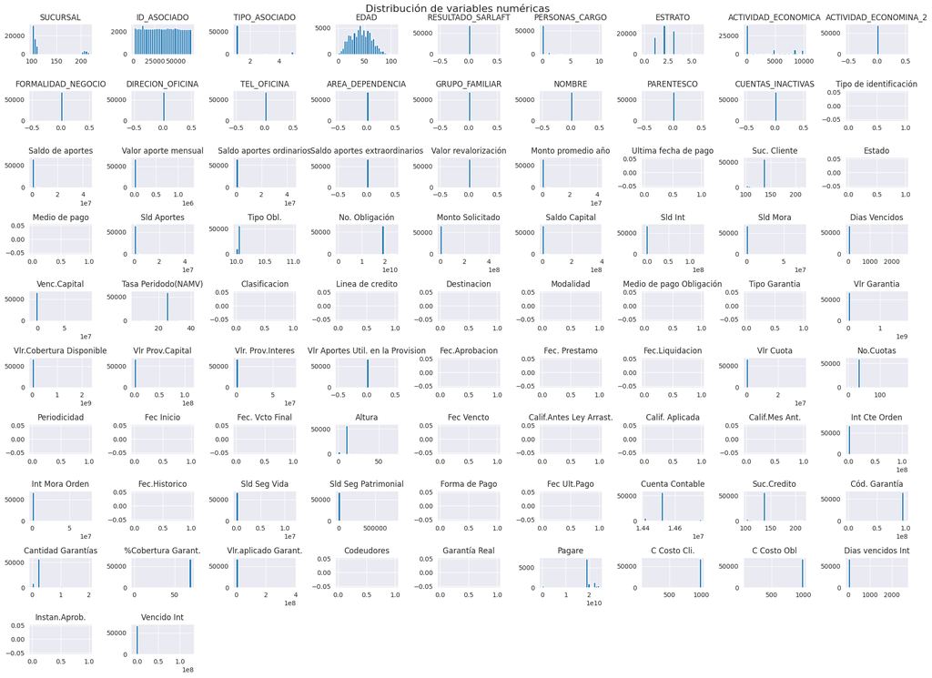

```python
# Gráfico de distribución de las variables numéricas

# 'hist()' genera histogramas para todas las columnas numéricas en el DataFrame.
# El parámetro 'figsize=(20, 15)' establece el tamaño del gráfico, asegurando que todos los histogramas se muestren adecuadamente.
# El parámetro 'bins=30' define el número de divisiones o contenedores (bins) utilizados en los histogramas.
merged_df.hist(figsize=(20, 15), bins=30)

# Título general del gráfico que resume el contenido de los subgráficos.
plt.suptitle("Distribución de variables numéricas", fontsize=16)

# 'tight_layout()' ajusta automáticamente el espaciado entre subgráficos para evitar que se superpongan.
plt.tight_layout()

# Mostrar todos los histogramas generados. Cada uno representa la distribución de una variable numérica.
plt.show()
```

En la imagen proporcionada, se observan histogramas que muestran la distribución de diversas variables numéricas en el DataFrame. Estos gráficos permiten identificar la concentración de datos en diferentes rangos de valores y detectar posibles sesgos o outliers.

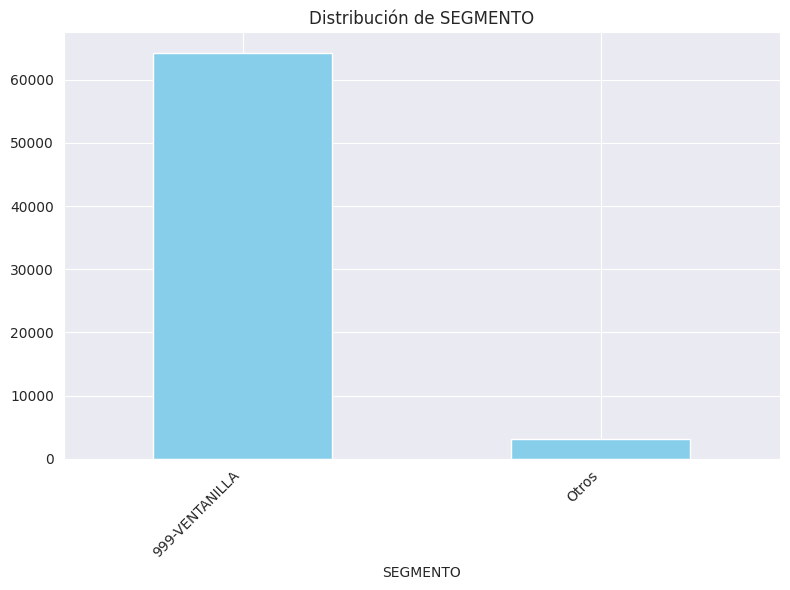

```python
# Gráfico de distribución para la columna SEGMENTO (con corrección para categorías pequeñas)

# Definir las columnas importantes que quieres analizar
# Se seleccionan algunas columnas relevantes para el análisis, relacionadas con datos demográficos y financieros.
columnas_importantes = [
    'EDAD', 'ESTRATO', 'GENERO', 'ESTADO_CIVIL',
    'Saldo de aportes', 'Monto Solicitado', 'Saldo Capital', 'Dias Vencidos',
    'SEGMENTO', 'TIPO_ASOCIADO'
]

# Filtrar el DataFrame para solo las columnas seleccionadas
# Se crea un nuevo DataFrame 'df_importante' con solo las columnas importantes seleccionadas previamente.
df_importante = merged_df[columnas_importantes]

# Agrupar las categorías menos frecuentes en 'SEGMENTO'
# El 'threshold' define el número mínimo de registros que debe tener una categoría para ser mostrada individualmente.
# Las categorías menos frecuentes que no alcanzan el umbral son agrupadas bajo la etiqueta 'Otros'.
threshold = 1000  # Establecer un umbral para agrupar categorías menos frecuentes
# Se utiliza 'loc' para evitar el 'SettingWithCopyWarning' al modificar el DataFrame de manera adecuada.
df_importante.loc[:, 'SEGMENTO'] = df_importante['SEGMENTO'].apply(lambda x: x if df_importante['SEGMENTO'].value_counts()[x] >= threshold else 'Otros')

# Gráfico de barras para la columna SEGMENTO
# Se genera un gráfico de barras donde se visualiza la distribución de las categorías en la columna 'SEGMENTO'.
plt.figure(figsize=(8, 6))  # Definir el tamaño de la figura
df_importante['SEGMENTO'].value_counts().plot(kind='bar', color='skyblue')  # Graficar los valores de 'SEGMENTO'
plt.title("Distribución de SEGMENTO")  # Título del gráfico
plt.xticks(rotation=45, ha='right')  # Rotar las etiquetas en el eje x para mejorar la legibilidad
plt.tight_layout()  # Ajustar el diseño para evitar la superposición
plt.show()  # Mostrar el gráfico final
```

En la gráfica adjunta se visualiza la distribución de la columna **SEGMENTO**, después de agrupar las categorías menos frecuentes bajo el grupo "Otros" debido a que no alcanzaban el umbral de 1000 registros. El gráfico muestra claramente que la categoría **"999-VENTANILLA"** domina la distribución con una cantidad significativa de registros, lo que indica que la mayoría de los datos se agrupan en este segmento específico. En contraste, las categorías agrupadas bajo **"Otros"** representan una pequeña proporción del total. Esto sugiere una concentración alta de registros en un segmento dominante, lo que puede reflejar una tendencia generalizada en el comportamiento de la población o clientes analizados.

```python
# Guardar el DataFrame procesado
# Guardar el DataFrame actualizado con las columnas agrupadas
output_path = '/home/usuario/PycharmProjects/cooperativas-data-analysis/output/merged_data_analizado.csv'
df_importante.to_csv(output_path, index=False)
print(f"DataFrame procesado guardado en: {output_path}")
```

```
DataFrame procesado guardado en: /home/usuario/PycharmProjects/cooperativas-data-analysis/output/merged_data_analizado.csv
```

## 7. Procesamiento de Datos Adicional

```python
# Cargar el archivo con los datos analizados
# Se define la ruta donde se encuentra almacenado el archivo CSV que contiene los datos analizados previamente.
archivo_analizado_path = '/home/usuario/PycharmProjects/cooperativas-data-analysis/output/merged_data_analizado.csv'

# Cargar el archivo CSV en un DataFrame de pandas
# Se utiliza 'pd.read_csv()' para cargar el archivo CSV en un DataFrame, configurando 'low_memory=False' para evitar advertencias sobre la mezcla de tipos de datos.
df = pd.read_csv(archivo_analizado_path, low_memory=False)

# Ver la información general del DataFrame antes de iniciar el procesamiento
# 'df.info()' proporciona un resumen de las columnas, sus tipos de datos, y la cantidad de valores no nulos, lo que permite entender la estructura del DataFrame antes de realizar modificaciones adicionales.
print("Información general del DataFrame antes del procesamiento:")
print(df.info())
```

```
Información general del DataFrame antes del procesamiento:
<class 'pandas.core.frame.DataFrame'>
RangeIndex: 67483 entries, 0 to 67482
Data columns (total 10 columns):
 #   Column            Non-Null Count  Dtype
---  ------            --------------  -----
 0   EDAD              67483 non-null  float64
 1   ESTRATO           67483 non-null  int64
 2   GENERO            67483 non-null  object
 3   ESTADO_CIVIL      67483 non-null  object
 4   Saldo de aportes  67483 non-null  float64
 5   Monto Solicitado  67483 non-null  float64
 6   Saldo Capital     67483 non-null  float64
 7   Dias Vencidos     67483 non-null  float64
 8   SEGMENTO          67483 non-null  object
 9   TIPO_ASOCIADO     67483 non-null  int64
dtypes: float64(5), int64(2), object(3)
memory usage: 5.1+ MB
None
```

```python
# Creación de nuevas variables (Transformaciones)

# Crear una nueva variable 'Rango_Edad' agrupando la columna 'EDAD' en categorías definidas por los límites en 'bins'.
# 'pd.cut()' se utiliza para clasificar la edad en rangos: por ejemplo, menores de 18, entre 18 y 30, etc.
df['Rango_Edad'] = pd.cut(df['EDAD'], bins=[0, 18, 30, 45, 60, 75, 90, 120],
                          labels=['Menor de 18', '18-30', '30-45', '45-60', '60-75', '75-90', 'Mayor de 90'])

# Normalización de la columna 'Monto Solicitado' usando min-max scaling.
# Este proceso ajusta los valores de 'Monto Solicitado' para que estén entre 0 y 1, lo que facilita comparaciones.
df['Monto_Solicitado_Normalizado'] = (df['Monto Solicitado'] - df['Monto Solicitado'].min()) / (df['Monto Solicitado'].max() - df['Monto Solicitado'].min())

# Crear una nueva columna binaria 'Saldo_Pos_Adeudado'.
# Si el valor de 'Saldo Capital' es mayor a 0, asignamos 1 (saldo pendiente). Si no, asignamos 0 (sin saldo).
df['Saldo_Pos_Adeudado'] = df['Saldo Capital'].apply(lambda x: 1 if x > 0 else 0)

# Mostrar las primeras filas del DataFrame con las nuevas columnas creadas.
# Visualizar una parte del DataFrame para verificar las transformaciones aplicadas.
print("Nuevas columnas creadas:")
print(df[['EDAD', 'Rango_Edad', 'Monto_Solicitado_Normalizado', 'Saldo_Pos_Adeudado']].head())
```

```
Nuevas columnas creadas:
   EDAD Rango_Edad  Monto_Solicitado_Normalizado  Saldo_Pos_Adeudado
0  65.0      60-75                      0.026765                   1
1  39.0      30-45                      0.026765                   1
2  48.0      45-60                      0.026765                   1
3  55.0      45-60                      0.009385                   1
4  28.0      18-30                      0.026765                   1
```

El análisis de las nuevas columnas creadas muestra que la columna **Rango_Edad** agrupa correctamente las edades en categorías predefinidas, facilitando el análisis por grupos de edad. La columna **Monto_Solicitado_Normalizado** escala los valores de "Monto Solicitado" entre 0 y 1, mostrando que, en este caso, la mayoría de los montos solicitados están en el rango bajo de la distribución. La columna **Saldo_Pos_Adeudado** indica que todos los registros de esta muestra tienen un saldo de capital pendiente, con el valor 1 asignado a cada fila. Estas transformaciones permiten un análisis más estructurado de las variables y son útiles para posteriores análisis o modelos predictivos.

```python
# Agregación de datos para obtener resúmenes importantes

# Eliminar advertencia 'FutureWarning' especificando el parámetro 'observed'
# Este warning aparece porque 'groupby' sobre columnas categóricas puede cambiar su comportamiento en futuras versiones de pandas.
# Se establece 'observed=True' para obtener solo las combinaciones observadas y evitar el warning.
# Agrupar por 'Rango_Edad' y sumar el 'Monto Solicitado' para cada grupo de edad
monto_por_rango_edad = df.groupby('Rango_Edad', observed=True)['Monto Solicitado'].sum()
print("Monto total solicitado por rango de edad:")
print(monto_por_rango_edad)

# Agrupar por 'SEGMENTO' y sumar tanto el 'Saldo de aportes' como el 'Saldo Capital'
# Esto muestra la suma total de ambos saldos por cada categoría del segmento
saldo_por_segmento = df.groupby('SEGMENTO', observed=True)[['Saldo de aportes', 'Saldo Capital']].sum()
print("Saldo total de aportes y capital por SEGMENTO:")
print(saldo_por_segmento)
```

```
Monto total solicitado por rango de edad:
Rango_Edad
Menor de 18    9.973921e+10
18-30          1.325514e+11
30-45          2.233589e+11
45-60          2.212289e+11
60-75          1.388850e+11
75-90          3.599983e+10
Mayor de 90    2.944795e+09
Name: Monto Solicitado, dtype: float64
Saldo total de aportes y capital por SEGMENTO:
                Saldo de aportes  Saldo Capital
SEGMENTO
999-VENTANILLA      2.231763e+10   5.562390e+11
Otros               8.141311e+09   4.810798e+10
```

En cuanto al saldo de aportes y capital por **SEGMENTO**, el segmento "999-VENTANILLA" acumula la mayor parte del saldo, con más de 5.5 x 10¹¹ en saldo de capital, lo que contrasta con el segmento "Otros", que tiene valores significativamente menores (aproximadamente 4.81 x 10¹⁰ en saldo de capital). Esto sugiere que la mayoría de las operaciones financieras y préstamos se concentran en el segmento "999-VENTANILLA".

```python
# Verificar los nombres de las columnas
print(df.columns)
```

```
Index(['EDAD', 'ESTRATO', 'GENERO', 'ESTADO_CIVIL', 'Saldo de aportes',
       'Monto Solicitado', 'Saldo Capital', 'Dias Vencidos', 'SEGMENTO',
       'TIPO_ASOCIADO', 'Rango_Edad', 'Monto_Solicitado_Normalizado',
       'Saldo_Pos_Adeudado'],
      dtype='object')
```

```python
# Normalización de la columna 'Monto Solicitado' usando min-max scaling.
# Este proceso ajusta los valores de 'Monto Solicitado' para que estén en un rango de [0, 1].
# Min-Max scaling permite que los valores más pequeños tomen el valor 0 y los mayores el valor 1.
df['Monto_Solicitado_Normalizado'] = (df['Monto Solicitado'] - df['Monto Solicitado'].min()) / (df['Monto Solicitado'].max() - df['Monto Solicitado'].min())

# Creación de una nueva columna binaria 'Saldo_Pos_Adeudado' que indica si hay deuda.
# Si el 'Saldo Capital' es mayor que 0, se asigna 1, lo que significa que hay deuda.
# Si el 'Saldo Capital' es igual a 0, se asigna 0, lo que indica que no hay deuda pendiente.
df['Saldo_Pos_Adeudado'] = df['Saldo Capital'].apply(lambda x: 1 if x > 0 else 0)

# Guardar el DataFrame procesado con las nuevas transformaciones en un archivo CSV.
# 'output_path' define la ubicación del archivo donde se guardarán los datos.
output_path = '/home/usuario/PycharmProjects/cooperativas-data-analysis/output/merged_data_procesado.csv'
df.to_csv(output_path, index=False)  # Se guarda el archivo sin los índices de las filas para mantener el archivo limpio.

# Confirmación en la consola de que el DataFrame procesado ha sido guardado correctamente.
print(f"DataFrame procesado y guardado en {output_path}")
```

```
DataFrame procesado y guardado en /home/usuario/PycharmProjects/cooperativas-data-analysis/output/merged_data_procesado.csv
```

## 8. Visualización de Resultados

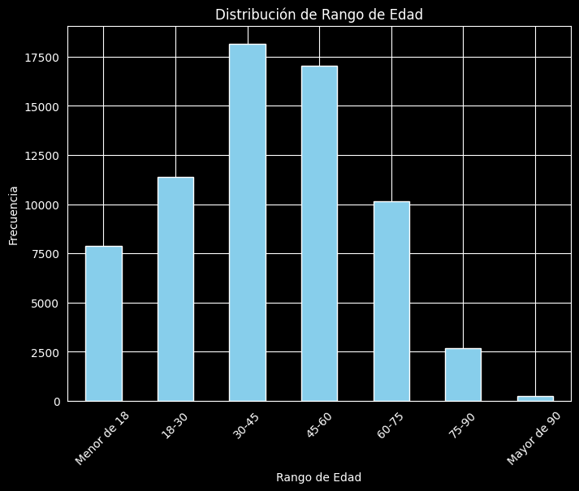

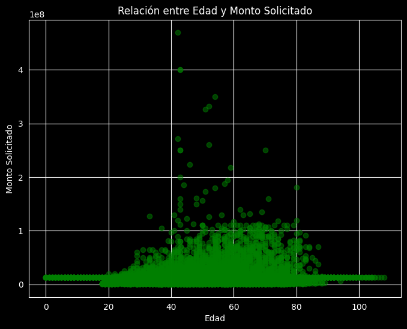

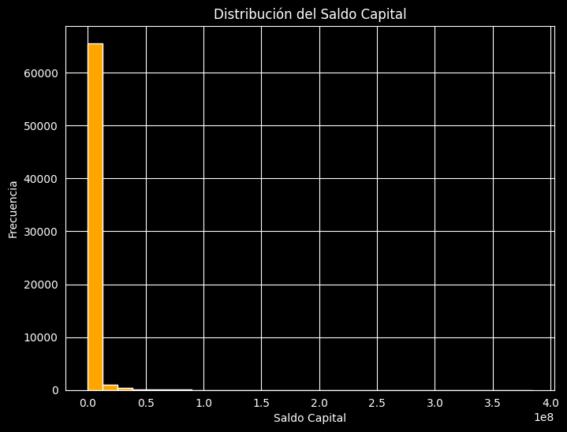

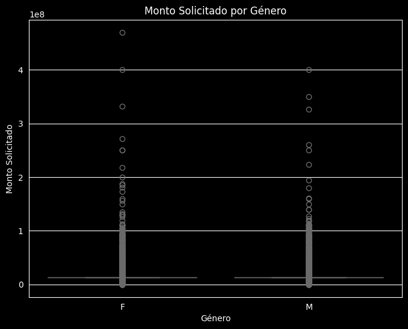

```python
# Configuración estética de los gráficos.
# 'dark_background' configura los gráficos con un fondo oscuro para mejorar el contraste visual.
plt.style.use('dark_background')

# Gráfico de barras para visualizar la distribución de la variable 'Rango_Edad'.
# 'value_counts()' cuenta la frecuencia de cada categoría en 'Rango_Edad'.
# 'sort_index()' asegura que los rangos se muestren en orden correcto.
plt.figure(figsize=(8, 6))  # Establece el tamaño del gráfico (ancho, alto).
df['Rango_Edad'].value_counts().sort_index().plot(kind='bar', color='skyblue')  # Gráfico de barras ordenado por 'Rango_Edad'.
plt.title('Distribución de Rango de Edad')  # Título del gráfico.
plt.xlabel('Rango de Edad')  # Etiqueta del eje x.
plt.ylabel('Frecuencia')  # Etiqueta del eje y.
plt.xticks(rotation=45)  # Rotar las etiquetas del eje x para evitar superposición.
plt.show()  # Muestra el gráfico.

# Gráfico de dispersión para visualizar la relación entre 'Monto Solicitado' y 'Edad'.
# Se usa un scatter plot para observar posibles correlaciones entre dos variables numéricas.
plt.figure(figsize=(8, 6))  # Tamaño del gráfico.
plt.scatter(df['EDAD'], df['Monto Solicitado'], alpha=0.5, color='green')  # Gráfico de dispersión con puntos verdes y transparencia (alpha).
plt.title('Relación entre Edad y Monto Solicitado')  # Título del gráfico.
plt.xlabel('Edad')  # Etiqueta del eje x.
plt.ylabel('Monto Solicitado')  # Etiqueta del eje y.
plt.show()  # Muestra el gráfico.

# Histograma para visualizar la distribución del 'Saldo Capital'.
# Un histograma permite observar la distribución de una variable numérica.
plt.figure(figsize=(8, 6))  # Establece el tamaño del gráfico.
df['Saldo Capital'].hist(bins=30, color='orange')  # Histograma con 30 bins (intervalos) y color naranja.
plt.title('Distribución del Saldo Capital')  # Título del gráfico.
plt.xlabel('Saldo Capital')  # Etiqueta del eje x.
plt.ylabel('Frecuencia')  # Etiqueta del eje y.
plt.show()  # Muestra el gráfico.

# Boxplot para comparar la distribución de 'Monto Solicitado' según 'GENERO'.
# Un boxplot permite comparar las distribuciones de una variable numérica para diferentes categorías.
plt.figure(figsize=(8, 6))  # Establece el tamaño del gráfico.
sns.boxplot(x='GENERO', y='Monto Solicitado', data=df)  # Gráfico de caja que muestra la relación entre 'GENERO' y 'Monto Solicitado'.
plt.title('Monto Solicitado por Género')  # Título del gráfico.
plt.xlabel('Género')  # Etiqueta del eje x.
plt.ylabel('Monto Solicitado')  # Etiqueta del eje y.
plt.show()  # Muestra el gráfico.
```

1. **Distribución por Rango de Edad**: La primera gráfica muestra la distribución de la población en diferentes rangos de edad. Podemos observar que los grupos más grandes están en las edades de **30-45** y **45-60**, lo que indica que la mayor cantidad de individuos que participan en el análisis están en edad productiva. Los grupos de edad más jóvenes (menores de 18 y entre 18-30) y los más avanzados (75-90 y mayores de 90) son considerablemente menores en frecuencia.
2. **Relación entre Edad y Monto Solicitado**: El gráfico de dispersión muestra la relación entre la **edad** y el **monto solicitado**. Observamos que la mayoría de las solicitudes de crédito se concentran en montos bajos, independientemente de la edad, con algunas solicitudes muy elevadas que corresponden a personas entre los 40 y 60 años, mostrando cierta concentración de montos altos en esas edades.
3. **Distribución del Saldo Capital**: El histograma de **Saldo Capital** muestra que la mayoría de los saldos de capital se encuentran en valores bajos, con una gran cantidad de registros cerca del valor cero. Esto sugiere que la mayoría de los participantes tienen poco saldo adeudado o han liquidado sus obligaciones, mientras que unos pocos tienen saldos significativamente más altos.
4. **Monto Solicitado por Género**: El boxplot muestra la distribución del **Monto Solicitado** por género. A primera vista, no hay una diferencia significativa entre hombres y mujeres en términos de montos solicitados. La mayoría de las solicitudes de ambos géneros son bajas, pero existen algunos valores atípicos (outliers) donde las solicitudes superan ampliamente el promedio, aunque estos casos son aislados.

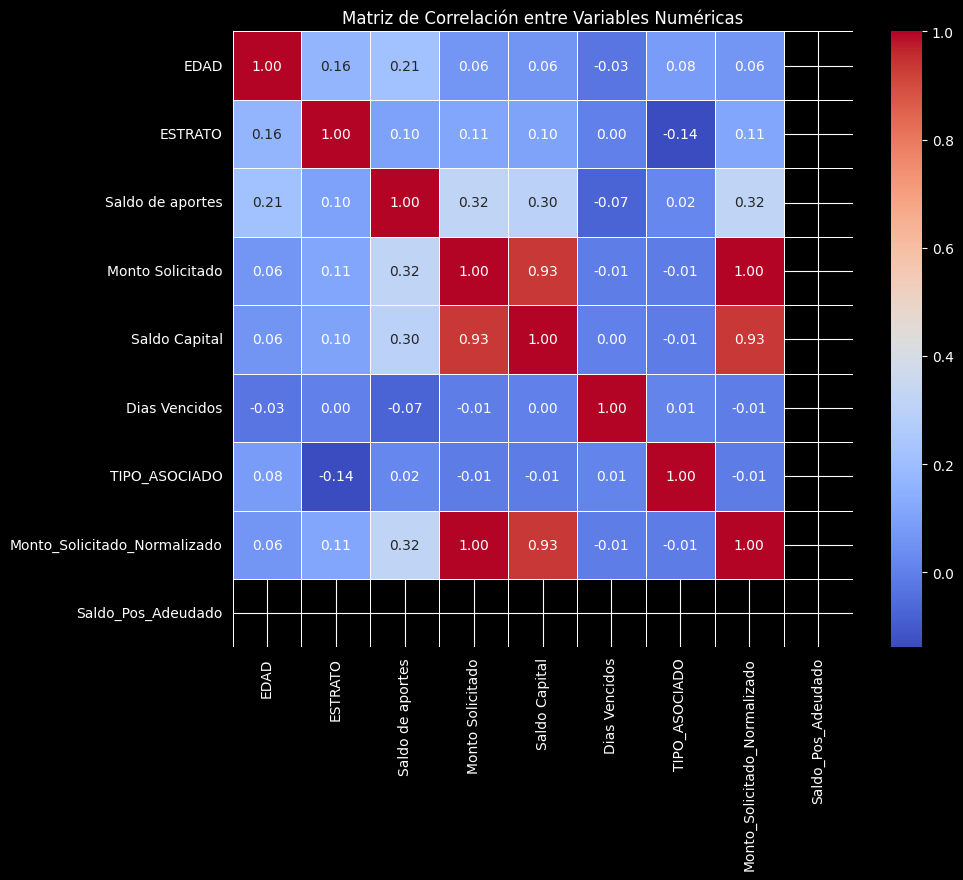

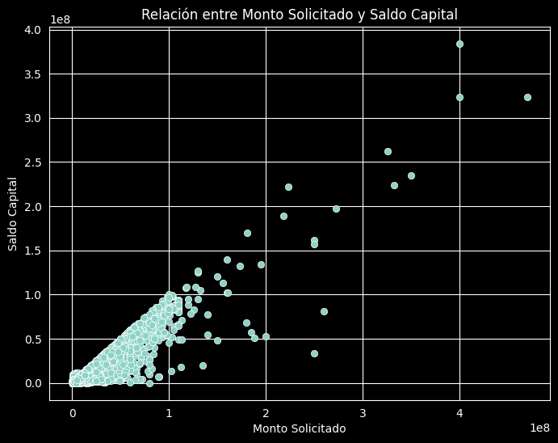

```python
# Filtrar solo las columnas numéricas
# Utilizamos 'select_dtypes' para seleccionar solo las columnas que contienen valores numéricos ('float64', 'int64')
# Esto asegura que trabajemos únicamente con las variables aptas para cálculos de correlación
df_numeric = df.select_dtypes(include=['float64', 'int64'])

# Cálculo de la matriz de correlación entre variables numéricas
# 'corr()' calcula el coeficiente de correlación entre las columnas seleccionadas, identificando relaciones lineales entre ellas
correlation_matrix = df_numeric.corr()

# Visualización de la matriz de correlación usando un heatmap
# Creamos un heatmap (mapa de calor) para representar visualmente la matriz de correlación
# figsize define el tamaño de la figura; annot=True añade los valores numéricos de la correlación sobre el mapa
# cmap especifica el color del mapa de calor y linewidths ajusta el grosor de las líneas divisorias entre las celdas
plt.figure(figsize=(10, 8))
sns.heatmap(correlation_matrix, annot=True, cmap='coolwarm', fmt='.2f', linewidths=0.5)
plt.title('Matriz de Correlación entre Variables Numéricas')  # Título del gráfico
plt.show()  # Mostrar el gráfico

# Opcional: Gráfico de dispersión para mostrar la relación entre dos variables con alta correlación
# Usamos un scatterplot (gráfico de dispersión) para visualizar la relación entre 'Monto Solicitado' y 'Saldo Capital'
plt.figure(figsize=(8, 6))  # Definimos el tamaño de la figura
sns.scatterplot(x='Monto Solicitado', y='Saldo Capital', data=df)  # Visualizamos los puntos de dispersión entre las dos variables
plt.title('Relación entre Monto Solicitado y Saldo Capital')  # Título del gráfico
plt.xlabel('Monto Solicitado')  # Etiqueta del eje X
plt.ylabel('Saldo Capital')  # Etiqueta del eje Y
plt.show()  # Mostrar el gráfico
```

El análisis de las gráficas obtenidas revela los siguientes puntos importantes:

1. **Matriz de Correlación**:
   - La matriz de correlación muestra relaciones numéricas entre varias variables del conjunto de datos.
   - La relación más fuerte (0.93) se observa entre las variables `Monto Solicitado` y `Saldo Capital`, lo cual es esperado, ya que un mayor monto solicitado está generalmente asociado a un mayor saldo de capital.
   - Las demás variables tienen correlaciones menores. Por ejemplo, `Edad` y `Saldo de Aportes` tienen una correlación moderada de 0.21, lo que podría indicar que personas de mayor edad tienden a tener un saldo de aportes más elevado.
   - Variables como `Dias Vencidos` y `TIPO_ASOCIADO` muestran una correlación muy baja o nula con las demás variables.
2. **Gráfico de Dispersión: Monto Solicitado vs. Saldo Capital**:
   - El gráfico de dispersión refuerza la correlación observada en la matriz. Existe una clara relación positiva entre `Monto Solicitado` y `Saldo Capital`.
   - La mayoría de los puntos se concentran en valores más bajos de ambas variables, lo que indica que muchas personas solicitan montos menores y tienen saldos de capital más bajos.
   - Sin embargo, hay algunos casos atípicos en los que se observan montos solicitados y saldos de capital significativamente más altos, representando una pequeña fracción de la población en análisis.

En resumen, las visualizaciones confirman que las variables financieras como `Monto Solicitado` y `Saldo Capital` están altamente correlacionadas, mientras que otras variables como `Edad` y `Estrato` no tienen una correlación tan fuerte con las métricas financieras clave. Los datos también sugieren la presencia de outliers, especialmente en los montos más elevados.

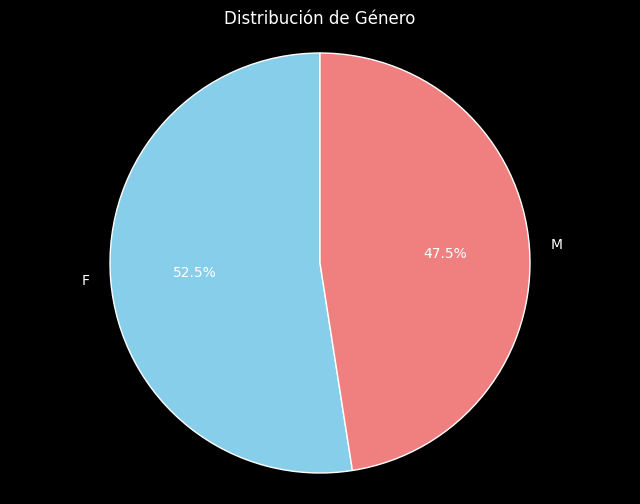

```python
# Contar las frecuencias de cada género
conteo_genero = df['GENERO'].value_counts()

# Crear gráfico de pastel
plt.figure(figsize=(8, 6))
plt.pie(conteo_genero, labels=conteo_genero.index, autopct='%1.1f%%', colors=['skyblue', 'lightcoral'], startangle=90)
plt.title('Distribución de Género')
plt.axis('equal')  # Asegura que el gráfico de pastel se vea circular
plt.show()
```

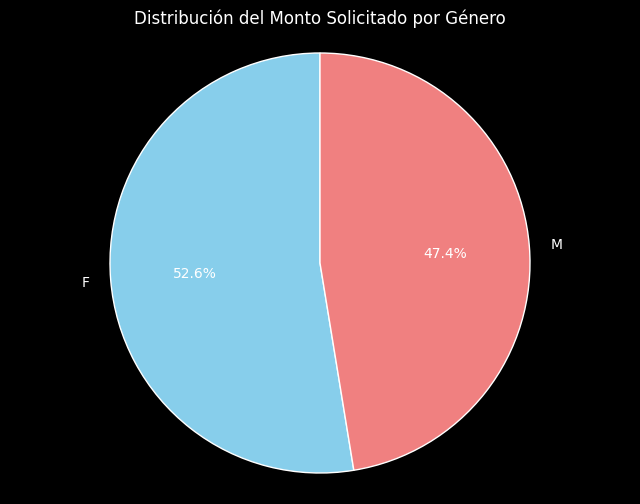

```python
# Sumar los montos solicitados por género
monto_por_genero = df.groupby('GENERO')['Monto Solicitado'].sum()

# Crear gráfico de pastel para Monto Solicitado por Género
plt.figure(figsize=(8, 6))
plt.pie(monto_por_genero, labels=monto_por_genero.index, autopct='%1.1f%%', colors=['skyblue', 'lightcoral'], startangle=90)
plt.title('Distribución del Monto Solicitado por Género')
plt.axis('equal')
plt.show()
```

Las gráficas de pastel muestran la distribución de género en dos escenarios clave:

1. **Distribución de Género**:
   - El gráfico muestra que la distribución de género está relativamente equilibrada en la base de datos. Las mujeres representan el 52.5% y los hombres el 47.5%. Esto sugiere que la mayoría de los registros están asociados a mujeres, aunque la diferencia con los hombres es pequeña.
2. **Distribución del Monto Solicitado por Género**:
   - La segunda gráfica, que ilustra la distribución del monto solicitado por género, refleja una proporción muy similar a la distribución de género general: el 52.6% del monto total solicitado corresponde a mujeres, mientras que el 47.4% corresponde a hombres. Este equilibrio indica que el comportamiento de solicitud de préstamos es bastante consistente con la proporción de género en la base de datos.

Ambos gráficos sugieren una paridad en términos de género tanto en la cantidad de registros como en el monto solicitado, con una ligera prevalencia femenina en ambos casos.

## Conclusiones

### Conclusiones y análisis del procedimiento

El procesamiento y análisis de datos realizado hasta el momento ha permitido extraer información valiosa sobre el comportamiento de los asociados en una cooperativa, desde sus características demográficas hasta el manejo de sus solicitudes financieras y aportes. Unificamos y limpiamos la base de datos, eliminando inconsistencias y realizando transformaciones que facilitaron la obtención de patrones y relaciones entre variables claves, como la edad, el género, el monto solicitado, el saldo de capital, y los días vencidos. Estas operaciones, como la normalización de montos y la creación de nuevas variables categóricas, facilitaron el análisis y nos permitieron visualizar los datos de manera clara.

El análisis por rangos de edad y género reveló patrones importantes. Por ejemplo, los datos indicaron que la mayoría de los montos solicitados se encuentran en personas entre los 30 y 60 años, lo cual puede señalar la etapa de la vida en la que los asociados necesitan más apoyo financiero. En cuanto a género, encontramos una ligera preponderancia en la participación de las mujeres tanto en la cantidad de registros como en los montos solicitados. Esto puede ser un dato crucial para la cooperativa al momento de diseñar productos financieros que se ajusten a las características de su base de asociados.

La visualización de la correlación entre las variables numéricas demostró una fuerte relación entre el **monto solicitado** y el **saldo de capital**, lo que es esperado ya que ambos dependen de las actividades financieras directas de los asociados. Sin embargo, la correlación fue baja o nula en otras variables, como los días vencidos o el tipo de asociado, lo cual indica que estas variables no están tan interrelacionadas con el comportamiento crediticio o con los montos solicitados.

### Importancia del tratamiento de datos

El tratamiento y unificación de los datos no es simplemente una tarea técnica, sino un aspecto estratégico para cualquier cooperativa. Permite centralizar la información y eliminar redundancias o errores, lo que a su vez facilita el análisis detallado y fiable. Esto es esencial para la toma de decisiones basadas en datos, especialmente en áreas críticas como la gestión de riesgos crediticios, la identificación de tendencias de comportamiento financiero, y el diseño de productos adaptados a las necesidades de los asociados.

Además, los datos bien tratados pueden ayudar a la cooperativa a cumplir con regulaciones financieras, mejorar la eficiencia operativa, y ofrecer mejores servicios a sus miembros. Por ejemplo, si la cooperativa puede identificar qué segmentos de edad o género son más propensos a necesitar ciertos productos financieros, puede ajustar su oferta para maximizar el impacto positivo en sus asociados.

### Uso de bases de datos vs. hojas de cálculo

En cuanto al almacenamiento y manejo de grandes volúmenes de datos, es evidente que el uso de **bases de datos** es mucho más eficiente y seguro que depender de hojas de cálculo como Excel. Aunque Excel es una herramienta valiosa para análisis rápidos y trabajos pequeños, presenta importantes limitaciones cuando los volúmenes de datos crecen, o cuando es necesario asegurar la integridad y el acceso concurrente a la información.

Las **bases de datos relacionales** o NoSQL permiten una mayor flexibilidad en la consulta de información, escalabilidad, seguridad y consistencia de los datos. Las cooperativas, que generalmente manejan una gran cantidad de datos sensibles y financieros, se beneficiarían enormemente de migrar de soluciones de hojas de cálculo a sistemas de bases de datos. Estos sistemas permiten la implementación de consultas complejas, agregación de datos, control de acceso, y una mayor capacidad para manejar grandes volúmenes de información de manera estructurada y eficiente.

### Sugerencias

1. **Adopción de un sistema de bases de datos**: La cooperativa debería considerar seriamente la adopción de un sistema de bases de datos, si aún no lo ha hecho. Esto garantizará la integridad de los datos, permitirá un análisis más sofisticado y reducirá los errores humanos.
2. **Automatización del procesamiento de datos**: Se recomienda implementar herramientas y scripts que permitan automatizar el procesamiento de datos. Esto incluye la limpieza, transformación y visualización de los datos, lo cual reducirá tiempos de procesamiento y aumentará la confiabilidad de los análisis.
3. **Análisis de datos avanzados**: Incorporar análisis más profundos como la segmentación de clientes, análisis predictivo, y técnicas de machine learning para identificar patrones en el comportamiento financiero de los asociados y optimizar la toma de decisiones.

### Impedimentos

1. **Calidad de los datos**: Un reto recurrente en el proceso fue la calidad de los datos, con múltiples columnas que tenían valores mixtos o faltantes. Esto subraya la importancia de que la cooperativa implemente mejores políticas de entrada y control de calidad de datos desde el origen.
2. **Resistencia al cambio**: Muchas organizaciones tienden a ser reacias a abandonar sistemas como Excel debido a la familiaridad de los empleados con estas herramientas. Es crucial que la cooperativa invierta en capacitación para facilitar la adopción de bases de datos y nuevas tecnologías.
3. **Infraestructura**: La migración a un sistema de bases de datos puede requerir inversiones en infraestructura tecnológica, tanto en términos de hardware como de software. Aunque es una inversión inicial importante, los beneficios a largo plazo superarán con creces los costos.

### Conclusión final

El tratamiento y análisis adecuado de los datos puede ofrecer una ventaja competitiva significativa para la cooperativa, permitiéndole optimizar su oferta de productos y mejorar su servicio a los asociados. El uso de bases de datos es, sin duda, una solución necesaria y eficiente para el manejo de información a gran escala, y su implementación debería ser una prioridad estratégica.